# R Notebook

# LOAD

```r
library(dplyr)
library(tidyr)
library(ggplot2)
library(data.table)
library(purrr)
library(forcats)
library(vegan)
library(tidyverse)
library(reshape2)
library(emmeans)
library(usedist)
library(compositions)
library(MASS)
library(tableone)
library(writexl)


load("/Users/danielavargasrobles/Dropbox (UMass Medical School)/Ana_projects/2_PREECLAMPSIA/P16S/meconium/phy_obj/PHY_fil_rar_alpha_meco.RData")
```

#table1

```r
# Load necessary libraries
#extract metadata
PHY_fil_rar_alpha_meco
```

```
phyloseq-class experiment-level object
otu_table()   OTU Table:         [ 454 taxa and 80 samples ]
sample_data() Sample Data:       [ 80 samples by 75 sample variables ]
tax_table()   Taxonomy Table:    [ 454 taxa by 7 taxonomic ranks ]
```

```r
met <- data.frame(sample_data(PHY_fil_rar_alpha_meco))

wilcox.test(met$shannon~met$study_group)
```

```
    Wilcoxon rank sum exact test

data:  met$shannon by met$study_group
W = 967, p-value = 0.06725
alternative hypothesis: true location shift is not equal to 0
```

```r
# Define variables
variables <- c("mod","term_status", "gestational_age", "sex_of_baby", "baby_nicu", "baby_weight",
               # "apgar_1", "apgar_5",
               "baby_temp_delivery", "ph_value", "days_stool1", "severe")

# Create the table
table_one <- CreateTableOne(vars = variables,
                          strata = "study_group",
                          data = met,
                          test = TRUE)


  table1_df <- print(table_one, quote = FALSE, noSpaces = TRUE, printToggle = FALSE,
                     showAllLevels = TRUE, includeNA = TRUE)
  table1_df
```

```
                                Stratified by study_group
                                 level               Control            PE
  n                              ""                  "40"               "39"
  mod (%)                        "Cesarean Delivery" "10 (25.0)"        "18 (46.2)"
                                 "Vaginal Delivery"  "30 (75.0)"        "21 (53.8)"
  term_status (%)                "preterm"           "0 (0.0)"          "12 (30.8)"
                                 "term"              "40 (100.0)"       "27 (69.2)"
  gestational_age (mean (SD))    ""                  "39.88 (0.88)"     "37.30 (2.26)"
  sex_of_baby (%)                "Female"            "24 (60.0)"        "21 (53.8)"
                                 "Male"              "16 (40.0)"        "18 (46.2)"
  baby_nicu (%)                  "No"                "36 (90.0)"        "26 (66.7)"
                                 "Yes"               "4 (10.0)"         "13 (33.3)"
  baby_weight (mean (SD))        ""                  "3543.00 (456.88)" "2867.82 (603.20)"
  baby_temp_delivery (mean (SD)) ""                  "37.08 (0.39)"     "36.29 (4.51)"
  ph_value (mean (SD))           ""                  "7.20 (0.07)"      "7.18 (0.10)"
  days_stool1 (mean (SD))        ""                  "0.65 (0.53)"      "1.16 (1.20)"
  severe (%)                     "No"                "0 (NaN)"          "19 (48.7)"
                                 "Yes"               "0 (NaN)"          "20 (51.3)"
                                Stratified by study_group
                                 p        test
  n                              ""       ""
  mod (%)                        "0.084"  ""
                                 ""       ""
  term_status (%)                "<0.001" ""
                                 ""       ""
  gestational_age (mean (SD))    "<0.001" ""
  sex_of_baby (%)                "0.745"  ""
                                 ""       ""
  baby_nicu (%)                  "0.024"  ""
                                 ""       ""
  baby_weight (mean (SD))        "<0.001" ""
  baby_temp_delivery (mean (SD)) "0.274"  ""
  ph_value (mean (SD))           "0.627"  ""
  days_stool1 (mean (SD))        "0.017"  ""
  severe (%)                     "NaN"    ""
                                 ""       ""
```

```r
# Define output directory with today's date
output_dir <- file.path("/Users/danielavargasrobles/Dropbox (UMass Medical School)/Ana_projects/2_PREECLAMPSIA/P16S/meconium/tables_clean", Sys.Date())
dir.create(output_dir, recursive = TRUE, showWarnings = FALSE)

# Save the table as a CSV file
write.csv(table1_df, file = file.path(output_dir, "table1_80.csv"))


#for severity#####################
# Load necessary libraries
#extract metadata

#only select PE samples
phy <- subset_samples(PHY_fil_rar_alpha_meco, study_group == "PE")
met <- data.frame(sample_data(phy))

# Define variables
variables <- c("mod","term_status", "gestational_age", "sex_of_baby", "baby_nicu", "baby_weight",# "apgar_1", "apgar_5",
               "baby_temp_delivery", "ph_value", "days_stool1" )

# Create the table
table_one <- CreateTableOne(vars = variables,
                          strata = "severe",
                          data = met,
                          test = TRUE)


  table1_df <- print(table_one, quote = FALSE, noSpaces = TRUE, printToggle = FALSE,
                     showAllLevels = TRUE, includeNA = TRUE)
  table1_df
```

```
                                Stratified by severe
                                 level               No                 Yes
  n                              ""                  "19"               "20"
  mod (%)                        "Cesarean Delivery" "7 (36.8)"         "11 (55.0)"
                                 "Vaginal Delivery"  "12 (63.2)"        "9 (45.0)"
  term_status (%)                "preterm"           "2 (10.5)"         "10 (50.0)"
                                 "term"              "17 (89.5)"        "10 (50.0)"
  gestational_age (mean (SD))    ""                  "38.20 (1.59)"     "36.44 (2.49)"
  sex_of_baby (%)                "Female"            "10 (52.6)"        "11 (55.0)"
                                 "Male"              "9 (47.4)"         "9 (45.0)"
  baby_nicu (%)                  "No"                "16 (84.2)"        "10 (50.0)"
                                 "Yes"               "3 (15.8)"         "10 (50.0)"
  baby_weight (mean (SD))        ""                  "3072.84 (480.96)" "2673.05 (653.13)"
  baby_temp_delivery (mean (SD)) ""                  "35.54 (6.44)"     "37.01 (0.50)"
  ph_value (mean (SD))           ""                  "7.20 (0.09)"      "7.17 (0.10)"
  days_stool1 (mean (SD))        ""                  "0.94 (1.39)"      "1.35 (0.99)"
                                Stratified by severe
                                 p       test
  n                              ""      ""
  mod (%)                        "0.415" ""
                                 ""      ""
  term_status (%)                "0.020" ""
                                 ""      ""
  gestational_age (mean (SD))    "0.013" ""
  sex_of_baby (%)                "1.000" ""
                                 ""      ""
  baby_nicu (%)                  "0.054" ""
                                 ""      ""
  baby_weight (mean (SD))        "0.037" ""
  baby_temp_delivery (mean (SD)) "0.314" ""
  ph_value (mean (SD))           "0.537" ""
  days_stool1 (mean (SD))        "0.304" ""
```

```r
# Define output directory with today's date
output_dir <- file.path("/Users/danielavargasrobles/Dropbox (UMass Medical School)/Ana_projects/2_PREECLAMPSIA/P16S/meconium/tables_clean", Sys.Date())
dir.create(output_dir, recursive = TRUE, showWarnings = FALSE)

# Save the table as a CSV file
write.csv(table1_df, file = file.path(output_dir, "table1_80_severity.csv"))



#3cat severity########
#for severity#####################
# Load necessary libraries
#extract metadata

#only select PE samples
met <- data.frame(sample_data(PHY_fil_rar_alpha_meco))

# Define variables
variables <- c("mod","term_status", "gestational_age", "sex_of_baby", "baby_nicu", "baby_weight",# "apgar_1", "apgar_5",
               "baby_temp_delivery", "ph_value", "days_stool1", "study_group")

# Create the table
table_one <- CreateTableOne(vars = variables,
                          strata = "severe_3cat",
                          data = met,
                          test = TRUE)


  table1_df <- print(table_one, quote = FALSE, noSpaces = TRUE, printToggle = FALSE,
                     showAllLevels = TRUE, includeNA = TRUE)
  table1_df
```

```
                                Stratified by severe_3cat
                                 level               control            No
  n                              ""                  "40"               "19"
  mod (%)                        "Cesarean Delivery" "10 (25.0)"        "7 (36.8)"
                                 "Vaginal Delivery"  "30 (75.0)"        "12 (63.2)"
  term_status (%)                "preterm"           "0 (0.0)"          "2 (10.5)"
                                 "term"              "40 (100.0)"       "17 (89.5)"
  gestational_age (mean (SD))    ""                  "39.88 (0.88)"     "38.20 (1.59)"
  sex_of_baby (%)                "Female"            "24 (60.0)"        "10 (52.6)"
                                 "Male"              "16 (40.0)"        "9 (47.4)"
  baby_nicu (%)                  "No"                "36 (90.0)"        "16 (84.2)"
                                 "Yes"               "4 (10.0)"         "3 (15.8)"
  baby_weight (mean (SD))        ""                  "3543.00 (456.88)" "3072.84 (480.96)"
  baby_temp_delivery (mean (SD)) ""                  "37.08 (0.39)"     "35.54 (6.44)"
  ph_value (mean (SD))           ""                  "7.20 (0.07)"      "7.20 (0.09)"
  days_stool1 (mean (SD))        ""                  "0.65 (0.53)"      "0.94 (1.39)"
  study_group (%)                "Control"           "40 (100.0)"       "0 (0.0)"
                                 "PE"                "0 (0.0)"          "19 (100.0)"
                                Stratified by severe_3cat
                                 Yes                p        test
  n                              "20"               ""       ""
  mod (%)                        "11 (55.0)"        "0.072"  ""
                                 "9 (45.0)"         ""       ""
  term_status (%)                "10 (50.0)"        "<0.001" ""
                                 "10 (50.0)"        ""       ""
  gestational_age (mean (SD))    "36.44 (2.49)"     "<0.001" ""
  sex_of_baby (%)                "11 (55.0)"        "0.849"  ""
                                 "9 (45.0)"         ""       ""
  baby_nicu (%)                  "10 (50.0)"        "0.001"  ""
                                 "10 (50.0)"        ""       ""
  baby_weight (mean (SD))        "2673.05 (653.13)" "<0.001" ""
  baby_temp_delivery (mean (SD)) "37.01 (0.50)"     "0.194"  ""
  ph_value (mean (SD))           "7.17 (0.10)"      "0.717"  ""
  days_stool1 (mean (SD))        "1.35 (0.99)"      "0.023"  ""
  study_group (%)                "0 (0.0)"          "<0.001" ""
                                 "20 (100.0)"       ""       ""
```

```r
# Define output directory with today's date
output_dir <- file.path("/Users/danielavargasrobles/Dropbox (UMass Medical School)/Ana_projects/2_PREECLAMPSIA/P16S/meconium/tables_clean", Sys.Date())
dir.create(output_dir, recursive = TRUE, showWarnings = FALSE)

# Save the table as a CSV file
write.csv(table1_df, file = file.path(output_dir, "table1_80_severity_3cat.csv"))
```

# table 1 all babies

```r
# Load necessary libraries
#extract metadata
# Cargar los datos
load("/Users/danielavargasrobles/Dropbox (UMass Medical School)/Ana_projects/2_PREECLAMPSIA/P16S/R/phy_objects/PHYrar_alpha_ggext_subset02_newseqs.RData")

phy= subset_samples(PHYrar_alpha_ggext_subset02_newseqs, body_site=="Vaginal")

met <- data.frame(sample_data(phy))
#filter only babies
met <- met[met$sample_type == "baby", ]
# Define variables
variables <- c("mod","term_status", "gestational_age", "sex_of_baby", "baby_nicu", "baby_weight",
               # "apgar_1", "apgar_5",
               "baby_temp_delivery", "ph_value", "days_stool1", "severe","study_group")

# Create the table
table_one <- CreateTableOne(vars = variables,
                          strata = "study_group",
                          data = met,
                          test = TRUE)
```

[output not shown]

#Colinealidad

```r
# Encode categorical variables numerically
met$study_group_numeric <- as.numeric(as.factor(met$study_group))
met$mod_numeric <- as.numeric(as.factor(met$mod))
#remove na stool day
met <- met[!is.na(met$days_stool1), ]
# Calculate the correlation matrix
cor_matrix <- cor(met[, c("study_group_numeric", "mod_numeric", "baby_weight", "days_stool1")], use = "complete.obs")

# Print the correlation matrix
print("Correlation matrix:")
```

```
[1] "Correlation matrix:"
```

```r
print(cor_matrix)
```

```
                    study_group_numeric mod_numeric baby_weight days_stool1
study_group_numeric           1.0000000  -0.2073636  -0.5420110   0.2695625
mod_numeric                  -0.2073636   1.0000000   0.2450843  -0.2223155
baby_weight                  -0.5420110   0.2450843   1.0000000  -0.3627280
days_stool1                   0.2695625  -0.2223155  -0.3627280   1.0000000
```

```r
library(car)

# Fit a linear model to calculate VIF
lm_model <- lm(study_group_numeric  ~  baby_weight+ mod_numeric + days_stool1, data = met)
vif_values <- vif(lm_model)

# Print VIF values
print("Variance Inflation Factors (VIF):")
```

```
[1] "Variance Inflation Factors (VIF):"
```

```r
print(vif_values)
```

```
baby_weight mod_numeric days_stool1
   1.190504    1.087622    1.177176
```

#ALPHA RLM additive (testing var) (Rubust linear model) the distribution of the dependent variables are too squeezed to the left, and no log transformation fix it so we use robust linear model with is less sensitive to outliers

```r
library(MASS)
library(lubridate)

PHY_fil_rar_alpha_meco
```

```
phyloseq-class experiment-level object
otu_table()   OTU Table:         [ 454 taxa and 80 samples ]
sample_data() Sample Data:       [ 80 samples by 75 sample variables ]
tax_table()   Taxonomy Table:    [ 454 taxa by 7 taxonomic ranks ]
```

```r
met <- data.frame(sample_data(PHY_fil_rar_alpha_meco))

met$mod
```

```
 [1] "Cesarean Delivery" "Vaginal Delivery"  "Cesarean Delivery" "Cesarean Delivery"
 [5] "Vaginal Delivery"  "Vaginal Delivery"  "Vaginal Delivery"  "Cesarean Delivery"
 [9] "Vaginal Delivery"  "Vaginal Delivery"  "Vaginal Delivery"  "Vaginal Delivery"
[13] "Cesarean Delivery" "Cesarean Delivery" "Vaginal Delivery"  "Vaginal Delivery"
[17] "Vaginal Delivery"  "Vaginal Delivery"  "Vaginal Delivery"  "Vaginal Delivery"
[21] "Vaginal Delivery"  "Cesarean Delivery" "Vaginal Delivery"  "Cesarean Delivery"
[25] "Cesarean Delivery" "Vaginal Delivery"  "Vaginal Delivery"  "Cesarean Delivery"
[29] "Cesarean Delivery" "Cesarean Delivery" "Vaginal Delivery"  "Vaginal Delivery"
[33] "Cesarean Delivery" "Vaginal Delivery"  "Cesarean Delivery" "Vaginal Delivery"
[37] "Vaginal Delivery"  "Vaginal Delivery"  "Vaginal Delivery"  "Vaginal Delivery"
[41] "Vaginal Delivery"  "Vaginal Delivery"  "Vaginal Delivery"  "Cesarean Delivery"
[45] "Vaginal Delivery"  "Vaginal Delivery"  "Cesarean Delivery" "Vaginal Delivery"
[49] "Vaginal Delivery"  "Vaginal Delivery"  "Vaginal Delivery"  "Vaginal Delivery"
[53] "Vaginal Delivery"  "Vaginal Delivery"  "Vaginal Delivery"  "Vaginal Delivery"
[57] "Cesarean Delivery" "Vaginal Delivery"  "Vaginal Delivery"  "Cesarean Delivery"
[61] "Vaginal Delivery"  "Cesarean Delivery" "Cesarean Delivery" "Cesarean Delivery"
[65] "Vaginal Delivery"  "Cesarean Delivery" "Vaginal Delivery"  "Cesarean Delivery"
[69] "Cesarean Delivery" "Vaginal Delivery"  "Vaginal Delivery"  "Cesarean Delivery"
[73] "Cesarean Delivery" "Vaginal Delivery"  "Vaginal Delivery"  "Vaginal Delivery"
[77] "Cesarean Delivery" "Vaginal Delivery"  "Cesarean Delivery" NA
```

```r
# Define the models using robust linear regression
rlm_sha <- rlm(shannon ~ study_group + baby_weight + days_stool1+baby_nicu +ethnicity+mod, data = met)
rlm_obs <- rlm(observed ~ study_group + baby_weight + days_stool1+baby_nicu+ethnicity+mod , data = met)
rlm_simp <- rlm(simpson ~ study_group + baby_weight + days_stool1 +baby_nicu+ethnicity+mod, data = met)


#shapiro
shapiro.test(residuals(rlm_sha))
```

```
    Shapiro-Wilk normality test

data:  residuals(rlm_sha)
W = 0.96268, p-value = 0.02208
```

```r
shapiro.test(residuals(rlm_obs))
```

```
    Shapiro-Wilk normality test

data:  residuals(rlm_obs)
W = 0.90684, p-value = 2.981e-05
```

```r
shapiro.test(residuals(rlm_simp))
```

```
    Shapiro-Wilk normality test

data:  residuals(rlm_simp)
W = 0.81393, p-value = 1.621e-08
```

```r
# Function to calculate results for a model
calculate_model_results <- function(model, model_name) {
    t_vals <- summary(model)$coefficients[, "t value"]
    df <- length(model$residuals) - length(model$coefficients)
    p_vals <- 2 * (1 - pt(abs(t_vals), df = df))

    results <- data.frame(
        Model = rep(model_name, length(t_vals)),
        Term = names(t_vals),
        Estimate = summary(model)$coefficients[, "Value"],
        Std_Error = summary(model)$coefficients[, "Std. Error"],
        t_value = t_vals,
        p_value = p_vals
    )
    return(results)
}

# Calculate results for all three models
sha_results <- calculate_model_results(rlm_sha, "Shannon")
obs_results <- calculate_model_results(rlm_obs, "Observed Species")
simp_results <- calculate_model_results(rlm_simp, "Simpson")

# Combine all results and round numeric columns
all_results <- rbind(sha_results, obs_results, simp_results)
numeric_cols <- sapply(all_results, is.numeric)
all_results[numeric_cols] <- round(all_results[numeric_cols], 4)

# Print combined results
print("Combined results for all diversity models:")
```

```
[1] "Combined results for all diversity models:"
```

```r
print(all_results)
```

|  | Model | Term | Estimate | Std_Error | t_value | p_value |
| --- | --- | --- | --- | --- | --- | --- |
| (Intercept) | Shannon | (Intercept) | 2.1418 | 0.7537 | 2.8416 | 0.0059 |
| study_groupPE | Shannon | study_groupPE | -0.1223 | 0.2235 | -0.5473 | 0.5859 |
| baby_weight | Shannon | baby_weight | 0.0002 | 0.0002 | 1.2322 | 0.2219 |
| days_stool1 | Shannon | days_stool1 | -0.1188 | 0.1083 | -1.0976 | 0.2761 |
| baby_nicuYes | Shannon | baby_nicuYes | -0.1803 | 0.2771 | -0.6506 | 0.5174 |
| ethnicityNot Hispanic/Latina | Shannon | ethnicityNot Hispanic/Latina | 0.0967 | 0.2174 | 0.4449 | 0.6577 |
| modVaginal Delivery | Shannon | modVaginal Delivery | 0.0426 | 0.2219 | 0.1919 | 0.8484 |
| (Intercept)1 | Observed Species | (Intercept) | 153.3521 | 24.1885 | 6.3399 | 0.0000 |
| study_groupPE1 | Observed Species | study_groupPE | -8.0330 | 7.1729 | -1.1199 | 0.2665 |
| baby_weight1 | Observed Species | baby_weight | 0.0064 | 0.0063 | 1.0255 | 0.3086 |

[output cut: 11 more lines]

```r
# Define output directory with today's date
output_dir <- file.path("/Users/danielavargasrobles/Dropbox (UMass Medical School)/Ana_projects/2_PREECLAMPSIA/P16S/meconium/res/alpha/rlm/", Sys.Date())
dir.create(output_dir, recursive = TRUE, showWarnings = FALSE)

# Save the table as a CSV file
write.csv(all_results, file = file.path(output_dir, "sg_bw_day_nicu_eth_mod.csv"))
```

# ALPHA RLM (final var)

```r
PHY_fil_rar_alpha_meco
```

```
phyloseq-class experiment-level object
otu_table()   OTU Table:         [ 454 taxa and 80 samples ]
sample_data() Sample Data:       [ 80 samples by 75 sample variables ]
tax_table()   Taxonomy Table:    [ 454 taxa by 7 taxonomic ranks ]
```

```r
met <- data.frame(sample_data(PHY_fil_rar_alpha_meco))

met$observed
```

```
 [1]  93 185  90 114 180  97 155 138  97 177 159 145 195 191 195 176 183 214 188 183 209 199
[23] 198 190 190 182 177 202 208 166 202 162 194 195 189 191 182 185 159 176 147 138 194  98
[45] 214 171 200 168 183 195 186 172 179 158 200 164 133 147 172 213 205 181 174 200 200 199
[67] 174 168 137 192 177 196 176 177 186 183 172 175 143 172
```

```r
# Define the models using robust linear regression
rlm_sha <- rlm(shannon ~ study_group + baby_weight , data = met)
rlm_obs <- rlm(observed ~ study_group + baby_weight  , data = met)
rlm_simp <- rlm(simpson ~ study_group + baby_weight , data = met)


#shapiro
shapiro.test(residuals(rlm_sha))
```

```
    Shapiro-Wilk normality test

data:  residuals(rlm_sha)
W = 0.96792, p-value = 0.04403
```

```r
shapiro.test(residuals(rlm_obs))
```

```
    Shapiro-Wilk normality test

data:  residuals(rlm_obs)
W = 0.89268, p-value = 6.814e-06
```

```r
shapiro.test(residuals(rlm_simp))
```

```
    Shapiro-Wilk normality test

data:  residuals(rlm_simp)
W = 0.81714, p-value = 1.728e-08
```

```r
# Function to calculate results for a model
calculate_model_results <- function(model, model_name) {
    t_vals <- summary(model)$coefficients[, "t value"]
    df <- length(model$residuals) - length(model$coefficients)
    p_vals <- 2 * (1 - pt(abs(t_vals), df = df))

    results <- data.frame(
        Model = rep(model_name, length(t_vals)),
        Term = names(t_vals),
        Estimate = summary(model)$coefficients[, "Value"],
        Std_Error = summary(model)$coefficients[, "Std. Error"],
        t_value = t_vals,
        p_value = p_vals
    )
    return(results)
}

# Calculate results for all three models
sha_results <- calculate_model_results(rlm_sha, "Shannon")
obs_results <- calculate_model_results(rlm_obs, "Observed Species")
simp_results <- calculate_model_results(rlm_simp, "Simpson")

# Combine all results and round numeric columns
all_results <- rbind(sha_results, obs_results, simp_results)
numeric_cols <- sapply(all_results, is.numeric)
all_results[numeric_cols] <- round(all_results[numeric_cols], 4)

# Print combined results
print("Combined results for all diversity models:")
```

```
[1] "Combined results for all diversity models:"
```

```r
print(all_results)
```

|  | Model | Term | Estimate | Std_Error | t_value | p_value |
| --- | --- | --- | --- | --- | --- | --- |
| (Intercept) | Shannon | (Intercept) | 1.7122 | 0.6400 | 2.6755 | 0.0091 |
| study_groupPE | Shannon | study_groupPE | -0.1417 | 0.2214 | -0.6398 | 0.5243 |
| baby_weight | Shannon | baby_weight | 0.0004 | 0.0002 | 2.0612 | 0.0427 |
| (Intercept)1 | Observed Species | (Intercept) | 167.9975 | 19.8667 | 8.4562 | 0.0000 |
| study_groupPE1 | Observed Species | study_groupPE | -5.6652 | 6.8734 | -0.8242 | 0.4124 |
| baby_weight1 | Observed Species | baby_weight | 0.0040 | 0.0055 | 0.7361 | 0.4639 |
| (Intercept)2 | Simpson | (Intercept) | 0.6111 | 0.0978 | 6.2471 | 0.0000 |
| study_groupPE2 | Simpson | study_groupPE | -0.0134 | 0.0338 | -0.3945 | 0.6943 |
| baby_weight2 | Simpson | baby_weight | 0.0001 | 0.0000 | 2.6316 | 0.0103 |

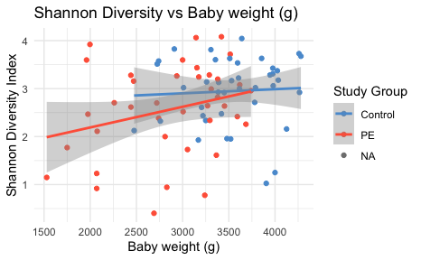

```r
# Define output directory with today's date
output_dir <- file.path("/Users/danielavargasrobles/Dropbox (UMass Medical School)/Ana_projects/2_PREECLAMPSIA/P16S/meconium/res/alpha/rlm/", Sys.Date())
dir.create(output_dir, recursive = TRUE, showWarnings = FALSE)

# Save the table as a CSV file
write.csv(all_results, file = file.path(output_dir, "sg_bw.csv"))


library(ggplot2)

# Create scatter plot for Shannon diversity
p1 <- ggplot(met, aes(x = baby_weight, y = shannon, color = study_group)) +
    geom_point() +
    geom_smooth(method = "lm", se = TRUE) +
    theme_minimal() +
  scale_color_manual(values = c("Control" = "#5a9bd4", "PE" = "#ff6347")) +
    labs(title = "Shannon Diversity vs Baby weight (g)",
         x = "Baby weight (g)",
         y = "Shannon Diversity Index",
         color = "Study Group")

print(p1)
# Save the plot as a PDF
ggsave(filename = file.path(output_dir, "Shannon_vs_baby_weight.pdf"),
       plot = p1, width = 6, height = 4)
```

# ALPHA RLM >2475g

The model with the interaction (study_group * baby_weight) is not significative so better leave the additive model

```r
# library(MASS)
# library(lubridate)
#
# PHY_fil_rar_alpha_meco
# met <- data.frame(sample_data(PHY_fil_rar_alpha_meco))
#
# met$observed
# # Define the models using robust linear regression
# rlm_sha <- rlm(shannon ~ study_group * baby_weight , data = met)
# rlm_obs <- rlm(observed ~ study_group * baby_weight , data = met)
# rlm_simp <- rlm(simpson ~ study_group * baby_weight , data = met)
#
#
# #shapiro
# shapiro.test(residuals(rlm_sha))
# shapiro.test(residuals(rlm_obs))
# shapiro.test(residuals(rlm_simp))
# # Function to calculate results for a model
# calculate_model_results <- function(model, model_name) {
#     t_vals <- summary(model)$coefficients[, "t value"]
#     df <- length(model$residuals) - length(model$coefficients)
#     p_vals <- 2 * (1 - pt(abs(t_vals), df = df))
#
#     results <- data.frame(
#         Model = rep(model_name, length(t_vals)),
#         Term = names(t_vals),
#         Estimate = summary(model)$coefficients[, "Value"],
#         Std_Error = summary(model)$coefficients[, "Std. Error"],
#         t_value = t_vals,
#         p_value = p_vals
#     )
#     return(results)
# }
#
# # Calculate results for all three models
# sha_results <- calculate_model_results(rlm_sha, "Shannon")
# obs_results <- calculate_model_results(rlm_obs, "Observed Species")
# simp_results <- calculate_model_results(rlm_simp, "Simpson")
#
# # Combine all results and round numeric columns
# all_results <- rbind(sha_results, obs_results, simp_results)
# numeric_cols <- sapply(all_results, is.numeric)
# all_results[numeric_cols] <- round(all_results[numeric_cols], 4)
#
# # Print combined results
# print("Combined results for all diversity models:")
# print(all_results)
#
# # Define output directory with today's date
# output_dir <- file.path("/Users/danielavargasrobles/Dropbox (UMass Medical School)/Ana_projects/2_PREECLAMPSIA/P16S/meconium/res/alpha/rlm/", Sys.Date())
# dir.create(output_dir, recursive = TRUE, showWarnings = FALSE)
#
# # Save the table as a CSV file
# write.csv(all_results, file = file.path(output_dir, "sd_bw_inter.csv"))
```

#boxplots study_group

```r
library(MASS)
library(lubridate)
PHY_fil_rar_alpha_meco
```

```
phyloseq-class experiment-level object
otu_table()   OTU Table:         [ 454 taxa and 80 samples ]
sample_data() Sample Data:       [ 80 samples by 75 sample variables ]
tax_table()   Taxonomy Table:    [ 454 taxa by 7 taxonomic ranks ]
```

```r
met <- data.frame(sample_data(PHY_fil_rar_alpha_meco))

met %>%
dplyr::select(study_group,baby_weight) %>%
  arrange(baby_weight)
```

|  | study_group | baby_weight |
| --- | --- | --- |
| B486 | PE | 1529 |
| B479 | PE | 1750 |
| B483 | PE | 1960 |
| B492 | PE | 1975 |
| B409 | PE | 1997 |
| B401 | PE | 2070 |
| B495 | PE | 2070 |
| B458 | PE | 2075 |
| B432 | PE | 2260 |
| B498 | PE | 2440 |

[output cut: 70 more lines]

```r
# # Filter data for gestational age >= 37.57 weeks
met %>%
  dplyr::select(baby_weight, study_group) %>%
  arrange(baby_weight)
```

|  | baby_weight | study_group |
| --- | --- | --- |
| B486 | 1529 | PE |
| B479 | 1750 | PE |
| B483 | 1960 | PE |
| B492 | 1975 | PE |
| B409 | 1997 | PE |
| B401 | 2070 | PE |
| B495 | 2070 | PE |
| B458 | 2075 | PE |
| B432 | 2260 | PE |
| B498 | 2440 | PE |

[output cut: 70 more lines]

```r
# filter 2475 or lower que es el peso mas bajo de controles
met <- subset(met, baby_weight >= 2470& baby_weight <= 3788)

library(MASS)
library(lubridate)

# # Define the models using robust linear regression
rlm_sha <- rlm(shannon ~ study_group+baby_weight , data = met)
rlm_obs <- rlm(observed ~ study_group+baby_weight, data = met)
rlm_simp <- rlm(simpson ~ study_group+baby_weight, data = met)

# Function to calculate results for a model
calculate_model_results <- function(model, model_name) {
    t_vals <- summary(model)$coefficients[, "t value"]
    df <- length(model$residuals) - length(model$coefficients)
    p_vals <- 2 * (1 - pt(abs(t_vals), df = df))

    results <- data.frame(
        Model = rep(model_name, length(t_vals)),
        Term = names(t_vals),
        Estimate = summary(model)$coefficients[, "Value"],
        Std_Error = summary(model)$coefficients[, "Std. Error"],
        t_value = t_vals,
        p_value = p_vals
    )
    return(results)
}

# Calculate results for all three models
sha_results <- calculate_model_results(rlm_sha, "Shannon")
obs_results <- calculate_model_results(rlm_obs, "Observed Species")
simp_results <- calculate_model_results(rlm_simp, "Simpson")

# Combine all results and round numeric columns
all_results <- rbind(sha_results, obs_results, simp_results)
numeric_cols <- sapply(all_results, is.numeric)
all_results[numeric_cols] <- round(all_results[numeric_cols], 4)

# Print combined results
print("Combined results for all diversity models:")
```

```
[1] "Combined results for all diversity models:"
```

```r
print(all_results)
```

|  | Model | Term | Estimate | Std_Error | t_value | p_value |
| --- | --- | --- | --- | --- | --- | --- |
| (Intercept) | Shannon | (Intercept) | 1.8864 | 1.0581 | 1.7829 | 0.0804 |
| study_groupPE | Shannon | study_groupPE | -0.1925 | 0.2106 | -0.9144 | 0.3647 |
| baby_weight | Shannon | baby_weight | 0.0003 | 0.0003 | 1.0276 | 0.3089 |
| (Intercept)1 | Observed Species | (Intercept) | 152.5055 | 37.1943 | 4.1002 | 0.0001 |
| study_groupPE1 | Observed Species | study_groupPE | -8.6520 | 7.4019 | -1.1689 | 0.2478 |
| baby_weight1 | Observed Species | baby_weight | 0.0085 | 0.0112 | 0.7650 | 0.4477 |
| (Intercept)2 | Simpson | (Intercept) | 0.7332 | 0.1483 | 4.9434 | 0.0000 |
| study_groupPE2 | Simpson | study_groupPE | -0.0172 | 0.0295 | -0.5822 | 0.5629 |
| baby_weight2 | Simpson | baby_weight | 0.0000 | 0.0000 | 0.8358 | 0.4071 |

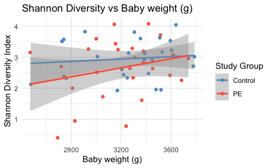

```r
#Define output directory with today's date
output_dir <- file.path("/Users/danielavargasrobles/Dropbox (UMass Medical School)/Ana_projects/2_PREECLAMPSIA/P16S/meconium/res/alpha/rlm/", Sys.Date())
dir.create(output_dir, recursive = TRUE, showWarnings = FALSE)

# Save the table as a CSV file
write.csv(all_results, file = file.path(output_dir, "more_than_baby_weight_range.csv"))

p1 <- ggplot(met, aes(x = baby_weight, y = shannon, color = study_group)) +
    geom_point() +
    geom_smooth(method = "lm", se = TRUE) +
    theme_minimal() +
  scale_color_manual(values = c("Control" = "#5a9bd4", "PE" = "#ff6347")) +
    labs(title = "Shannon Diversity vs Baby weight (g)",
         x = "Baby weight (g)",
         y = "Shannon Diversity Index",
         color = "Study Group")

print(p1)
ggsave(filename = file.path(output_dir, "Shannon_vs_baby_weight_range.pdf"),
       plot = p1, width = 6, height = 4)
```

#wilcox

```r
library(ggprism)
library(tidyr)
library(dplyr)
PHY_fil_rar_alpha_meco
```

```
phyloseq-class experiment-level object
otu_table()   OTU Table:         [ 454 taxa and 80 samples ]
sample_data() Sample Data:       [ 80 samples by 75 sample variables ]
tax_table()   Taxonomy Table:    [ 454 taxa by 7 taxonomic ranks ]
```

```r
met <- data.frame(sample_data(PHY_fil_rar_alpha_meco))

#remove NA in study_group
met <- met[!is.na(met$study_group), ]


# Convertir los datos a formato largo
met_long <- met %>%
  dplyr::select(study_group, observed, shannon, simpson) %>%
  pivot_longer(cols = c(observed, shannon, simpson),
               names_to = "measure",
               values_to = "value")

# Convertir measure a factor con el orden deseado
met_long$measure <- factor(met_long$measure,
                          levels = c("observed", "shannon", "simpson"),
                          labels = c("Observed", "Shannon", "Simpson"))

# Crear el gráfico
p1=ggplot(met_long, aes(x = study_group, y = value, fill = study_group)) +
    geom_boxplot(outlier.shape = NA) +
    geom_jitter(position = position_jitter(width = 0.2), size = 3, alpha = 0.6) +
    facet_wrap(~measure, scales = "free_y") +
    labs(x = "Study Group",
         y = "Alpha Diversity") +
    scale_fill_manual(values = c("Control" = "#5a9bd4", "PE" = "#ff6347")) +
    theme_prism(base_size = 16) +
    theme(axis.text.x = element_text(size = 14),
          axis.text.y = element_text(size = 14),
          axis.title.x = element_text(size = 16),
          axis.title.y = element_text(size = 16),
          plot.title = element_text(size = 18),
          strip.text = element_text(size = 16),
          legend.title = element_text(size = 16),
          legend.text = element_text(size = 14),
          legend.position = "none")

ggsave(filename = file.path(output_dir, "Shannon_sg.pdf"),
       plot = p1, width = 6, height = 4)
```

#ALPHA severe (testing var)

```r
# Wilcoxon test for Shannon diversity
wilcox_test_shannon <- wilcox.test(shannon ~ study_group, data = met)
print(wilcox_test_shannon)
```

```
    Wilcoxon rank sum exact test

data:  shannon by study_group
W = 967, p-value = 0.06725
alternative hypothesis: true location shift is not equal to 0
```

```r
# Wilcoxon test for Simpson diversity
wilcox_test_simpson <- wilcox.test(simpson ~ study_group, data = met)
print(wilcox_test_simpson)
```

```
    Wilcoxon rank sum exact test

data:  simpson by study_group
W = 973, p-value = 0.0588
alternative hypothesis: true location shift is not equal to 0
```

```r
# Wilcoxon test for Observed species
wilcox_test_observed <- wilcox.test(observed ~ study_group, data = met)
print(wilcox_test_observed)
```

```
    Wilcoxon rank sum test with continuity correction

data:  observed by study_group
W = 939.5, p-value = 0.1188
alternative hypothesis: true location shift is not equal to 0
```

# ALPHA severe (final) RLM

el modelo con la interaccion no es significato (study_group * baby_weight) Entonces em mejor modelo es el aditivo

```r
library(MASS)
library(lubridate)

PHY_fil_rar_alpha_meco
```

```
phyloseq-class experiment-level object
otu_table()   OTU Table:         [ 454 taxa and 80 samples ]
sample_data() Sample Data:       [ 80 samples by 75 sample variables ]
tax_table()   Taxonomy Table:    [ 454 taxa by 7 taxonomic ranks ]
```

```r
phy <- subset_samples(PHY_fil_rar_alpha_meco, severe_3cat != "control")

met <- data.frame(sample_data(PHY_fil_rar_alpha_meco))

met$mod
```

```
 [1] "Cesarean Delivery" "Vaginal Delivery"  "Cesarean Delivery" "Cesarean Delivery"
 [5] "Vaginal Delivery"  "Vaginal Delivery"  "Vaginal Delivery"  "Cesarean Delivery"
 [9] "Vaginal Delivery"  "Vaginal Delivery"  "Vaginal Delivery"  "Vaginal Delivery"
[13] "Cesarean Delivery" "Cesarean Delivery" "Vaginal Delivery"  "Vaginal Delivery"
[17] "Vaginal Delivery"  "Vaginal Delivery"  "Vaginal Delivery"  "Vaginal Delivery"
[21] "Vaginal Delivery"  "Cesarean Delivery" "Vaginal Delivery"  "Cesarean Delivery"
[25] "Cesarean Delivery" "Vaginal Delivery"  "Vaginal Delivery"  "Cesarean Delivery"
[29] "Cesarean Delivery" "Cesarean Delivery" "Vaginal Delivery"  "Vaginal Delivery"
[33] "Cesarean Delivery" "Vaginal Delivery"  "Cesarean Delivery" "Vaginal Delivery"
[37] "Vaginal Delivery"  "Vaginal Delivery"  "Vaginal Delivery"  "Vaginal Delivery"
[41] "Vaginal Delivery"  "Vaginal Delivery"  "Vaginal Delivery"  "Cesarean Delivery"
[45] "Vaginal Delivery"  "Vaginal Delivery"  "Cesarean Delivery" "Vaginal Delivery"
[49] "Vaginal Delivery"  "Vaginal Delivery"  "Vaginal Delivery"  "Vaginal Delivery"
[53] "Vaginal Delivery"  "Vaginal Delivery"  "Vaginal Delivery"  "Vaginal Delivery"
[57] "Cesarean Delivery" "Vaginal Delivery"  "Vaginal Delivery"  "Cesarean Delivery"
[61] "Vaginal Delivery"  "Cesarean Delivery" "Cesarean Delivery" "Cesarean Delivery"
[65] "Vaginal Delivery"  "Cesarean Delivery" "Vaginal Delivery"  "Cesarean Delivery"
[69] "Cesarean Delivery" "Vaginal Delivery"  "Vaginal Delivery"  "Cesarean Delivery"
[73] "Cesarean Delivery" "Vaginal Delivery"  "Vaginal Delivery"  "Vaginal Delivery"
[77] "Cesarean Delivery" "Vaginal Delivery"  "Cesarean Delivery" NA
```

```r
# Define the models using robust linear regression
rlm_sha <- rlm(shannon ~ severe + baby_weight + days_stool1+baby_nicu +ethnicity+mod, data = met)
rlm_obs <- rlm(observed ~ severe + baby_weight + days_stool1+baby_nicu+ethnicity+mod , data = met)
rlm_simp <- rlm(simpson ~ severe + baby_weight + days_stool1 +baby_nicu+ethnicity+mod, data = met)


#shapiro
shapiro.test(residuals(rlm_sha))
```

```
    Shapiro-Wilk normality test

data:  residuals(rlm_sha)
W = 0.98121, p-value = 0.7603
```

```r
shapiro.test(residuals(rlm_obs))
```

```
    Shapiro-Wilk normality test

data:  residuals(rlm_obs)
W = 0.94808, p-value = 0.07696
```

```r
shapiro.test(residuals(rlm_simp))
```

```
    Shapiro-Wilk normality test

data:  residuals(rlm_simp)
W = 0.92319, p-value = 0.01231
```

```r
# Function to calculate results for a model
calculate_model_results <- function(model, model_name) {
    t_vals <- summary(model)$coefficients[, "t value"]
    df <- length(model$residuals) - length(model$coefficients)
    p_vals <- 2 * (1 - pt(abs(t_vals), df = df))

    results <- data.frame(
        Model = rep(model_name, length(t_vals)),
        Term = names(t_vals),
        Estimate = summary(model)$coefficients[, "Value"],
        Std_Error = summary(model)$coefficients[, "Std. Error"],
        t_value = t_vals,
        p_value = p_vals
    )
    return(results)
}

# Calculate results for all three models
sha_results <- calculate_model_results(rlm_sha, "Shannon")
obs_results <- calculate_model_results(rlm_obs, "Observed Species")
simp_results <- calculate_model_results(rlm_simp, "Simpson")

# Combine all results and round numeric columns
all_results <- rbind(sha_results, obs_results, simp_results)
numeric_cols <- sapply(all_results, is.numeric)
all_results[numeric_cols] <- round(all_results[numeric_cols], 4)

# Print combined results
print("Combined results for all diversity models:")
```

```
[1] "Combined results for all diversity models:"
```

```r
print(all_results)
```

|  | Model | Term | Estimate | Std_Error | t_value | p_value |
| --- | --- | --- | --- | --- | --- | --- |
| (Intercept) | Shannon | (Intercept) | 2.4925 | 0.9162 | 2.7204 | 0.0106 |
| severeYes | Shannon | severeYes | -1.0325 | 0.3061 | -3.3732 | 0.0020 |
| baby_weight | Shannon | baby_weight | 0.0001 | 0.0003 | 0.2606 | 0.7961 |
| days_stool1 | Shannon | days_stool1 | -0.1743 | 0.1260 | -1.3838 | 0.1763 |
| baby_nicuYes | Shannon | baby_nicuYes | 0.2002 | 0.3701 | 0.5409 | 0.5925 |
| ethnicityNot Hispanic/Latina | Shannon | ethnicityNot Hispanic/Latina | 0.6599 | 0.3334 | 1.9792 | 0.0567 |
| modVaginal Delivery | Shannon | modVaginal Delivery | 0.0969 | 0.3416 | 0.2836 | 0.7786 |
| (Intercept)1 | Observed Species | (Intercept) | 144.9270 | 38.6352 | 3.7512 | 0.0007 |
| severeYes1 | Observed Species | severeYes | -1.6413 | 12.9076 | -0.1272 | 0.8996 |
| baby_weight1 | Observed Species | baby_weight | -0.0039 | 0.0122 | -0.3220 | 0.7496 |

[output cut: 11 more lines]

```r
# Define output directory with today's date
output_dir <- file.path("/Users/danielavargasrobles/Dropbox (UMass Medical School)/Ana_projects/2_PREECLAMPSIA/P16S/meconium/res/alpha/rlm/", Sys.Date())
dir.create(output_dir, recursive = TRUE, showWarnings = FALSE)

# Save the table as a CSV file
write.csv(all_results, file = file.path(output_dir, "sev_bw_day_nicu_eth_mod.csv"))
```

#boxplots severe

```r
library(MASS)
library(lubridate)
phy=PHY_fil_rar_alpha_meco
phy <- subset_samples(phy, !is.na(study_group))

phy <- subset_samples(phy, severe_3cat != "control")

met <- data.frame(sample_data(phy))

library(MASS)
library(lubridate)

# # Define the models using robust linear regression
rlm_sha <- rlm(shannon ~ severe+baby_weight   , data = met)
rlm_obs <- rlm(observed ~ severe+baby_weight  , data = met)
rlm_simp <- rlm(simpson ~ severe+baby_weight , data = met)

# Function to calculate results for a model
calculate_model_results <- function(model, model_name) {
    t_vals <- summary(model)$coefficients[, "t value"]
    df <- length(model$residuals) - length(model$coefficients)
    p_vals <- 2 * (1 - pt(abs(t_vals), df = df))

    results <- data.frame(
        Model = rep(model_name, length(t_vals)),
        Term = names(t_vals),
        Estimate = summary(model)$coefficients[, "Value"],
        Std_Error = summary(model)$coefficients[, "Std. Error"],
        t_value = t_vals,
        p_value = p_vals
    )
    return(results)
}

# Calculate results for all three models
sha_results <- calculate_model_results(rlm_sha, "Shannon")
obs_results <- calculate_model_results(rlm_obs, "Observed Species")
simp_results <- calculate_model_results(rlm_simp, "Simpson")

# Combine all results and round numeric columns
all_results <- rbind(sha_results, obs_results, simp_results)
numeric_cols <- sapply(all_results, is.numeric)
all_results[numeric_cols] <- round(all_results[numeric_cols], 4)

# Print combined results
print("Combined results for all diversity models:")
```

```
[1] "Combined results for all diversity models:"
```

```r
print(all_results)
```

|  | Model | Term | Estimate | Std_Error | t_value | p_value |
| --- | --- | --- | --- | --- | --- | --- |
| (Intercept) | Shannon | (Intercept) | 2.4167 | 0.7672 | 3.1501 | 0.0033 |
| severeYes | Shannon | severeYes | -0.8765 | 0.2877 | -3.0464 | 0.0043 |
| baby_weight | Shannon | baby_weight | 0.0002 | 0.0002 | 0.9222 | 0.3626 |
| (Intercept)1 | Observed Species | (Intercept) | 172.2408 | 30.6221 | 5.6247 | 0.0000 |
| severeYes1 | Observed Species | severeYes | 0.4175 | 11.4848 | 0.0364 | 0.9712 |
| baby_weight1 | Observed Species | baby_weight | -0.0005 | 0.0096 | -0.0569 | 0.9549 |
| (Intercept)2 | Simpson | (Intercept) | 0.6692 | 0.1568 | 4.2685 | 0.0001 |
| severeYes2 | Simpson | severeYes | -0.1786 | 0.0588 | -3.0384 | 0.0044 |
| baby_weight2 | Simpson | baby_weight | 0.0001 | 0.0000 | 1.3606 | 0.1821 |

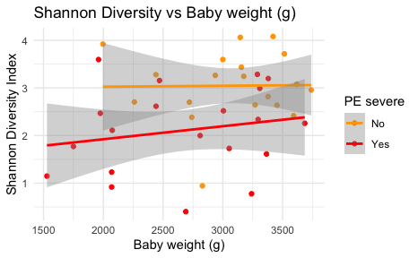

```r
#Define output directory with today's date
output_dir <- file.path("/Users/danielavargasrobles/Dropbox (UMass Medical School)/Ana_projects/2_PREECLAMPSIA/P16S/meconium/res/alpha/rlm/severe/", Sys.Date())
dir.create(output_dir, recursive = TRUE, showWarnings = FALSE)

# Save the table as a CSV file
write.csv(all_results, file = file.path(output_dir, "sev_bw.csv"))

p1 <- ggplot(met, aes(x = baby_weight, y = shannon, color = severe)) +
    geom_point() +
    geom_smooth(method = "lm", se = TRUE) +
    theme_minimal() +
  scale_color_manual(values = c("Yes" = "red", "No" = "orange")) +
    labs(title = "Shannon Diversity vs Baby weight (g)",
         x = "Baby weight (g)",
         y = "Shannon Diversity Index",
         color = "PE severe")

print(p1)
ggsave(filename = file.path(output_dir, "Shannon_vs_severe.pdf"),
       plot = p1, width = 6, height = 4)
```

#ALPHA severe 3 cat

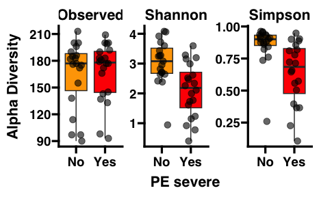

```r
library(ggprism)
library(tidyr)
library(dplyr)
phy<-PHY_fil_rar_alpha_meco
phy <- subset_samples(phy, !is.na(study_group))

phy <- subset_samples(phy, severe_3cat != "control")

met <- data.frame(sample_data(phy))

#remove NA in severe
met <- met[!is.na(met$severe), ]


# Convertir los datos a formato largo
met_long <- met %>%
  dplyr::select(severe, observed, shannon, simpson) %>%
  pivot_longer(cols = c(observed, shannon, simpson),
               names_to = "measure",
               values_to = "value")

# Convertir measure a factor con el orden deseado
met_long$measure <- factor(met_long$measure,
                          levels = c("observed", "shannon", "simpson"),
                          labels = c("Observed", "Shannon", "Simpson"))

# Crear el gráfico
p1=ggplot(met_long, aes(x = severe, y = value, fill = severe)) +
    geom_boxplot(outlier.shape = NA) +
    geom_jitter(position = position_jitter(width = 0.2), size = 3, alpha = 0.6) +
    facet_wrap(~measure, scales = "free_y") +
    labs(x = "PE severe",
         y = "Alpha Diversity") +
    scale_fill_manual(values = c("Yes" = "red", "No" = "orange")) +
    theme_prism(base_size = 16) +
    theme(axis.text.x = element_text(size = 14),
          axis.text.y = element_text(size = 14),
          axis.title.x = element_text(size = 16),
          axis.title.y = element_text(size = 16),
          plot.title = element_text(size = 18),
          strip.text = element_text(size = 16),
          legend.title = element_text(size = 16),
          legend.text = element_text(size = 14),
          legend.position = "none")

print(p1)
ggsave(filename = file.path( "/Users/danielavargasrobles/Dropbox (UMass Medical School)/Ana_projects/2_PREECLAMPSIA/P16S/meconium/res/alpha/rlm/severe/Shannon_severe.pdf"),
       plot = p1, width = 6, height = 4)
```

#boxplots severe 3cat

```r
library(MASS)
library(lubridate)
phy=PHY_fil_rar_alpha_meco
phy <- subset_samples(phy, !is.na(study_group))


met <- data.frame(sample_data(phy))

met$severe_3cat <- factor(met$severe_3cat, levels = c("No", "Yes", "control"))

# # Define the models using robust linear regression
rlm_sha <- rlm(shannon ~ severe_3cat+baby_weight   , data = met)
rlm_obs <- rlm(observed ~ severe_3cat+baby_weight  , data = met)
rlm_simp <- rlm(simpson ~ severe_3cat+baby_weight , data = met)

# Function to calculate results for a model
calculate_model_results <- function(model, model_name) {
    t_vals <- summary(model)$coefficients[, "t value"]
    df <- length(model$residuals) - length(model$coefficients)
    p_vals <- 2 * (1 - pt(abs(t_vals), df = df))

    results <- data.frame(
        Model = rep(model_name, length(t_vals)),
        Term = names(t_vals),
        Estimate = summary(model)$coefficients[, "Value"],
        Std_Error = summary(model)$coefficients[, "Std. Error"],
        t_value = t_vals,
        p_value = p_vals
    )
    return(results)
}

# Calculate results for all three models
sha_results <- calculate_model_results(rlm_sha, "Shannon")
obs_results <- calculate_model_results(rlm_obs, "Observed Species")
simp_results <- calculate_model_results(rlm_simp, "Simpson")

# Combine all results and round numeric columns
all_results <- rbind(sha_results, obs_results, simp_results)
numeric_cols <- sapply(all_results, is.numeric)
all_results[numeric_cols] <- round(all_results[numeric_cols], 4)

# Print combined results
print("Combined results for all diversity models:")
```

```
[1] "Combined results for all diversity models:"
```

```r
print(all_results)
```

|  | Model | Term | Estimate | Std_Error | t_value | p_value |
| --- | --- | --- | --- | --- | --- | --- |
| (Intercept) | Shannon | (Intercept) | 2.4805 | 0.5398 | 4.5947 | 0.0000 |
| severe_3catYes | Shannon | severe_3catYes | -0.8846 | 0.2500 | -3.5391 | 0.0007 |
| severe_3catcontrol | Shannon | severe_3catcontrol | -0.2037 | 0.2237 | -0.9108 | 0.3653 |
| baby_weight | Shannon | baby_weight | 0.0002 | 0.0002 | 1.2164 | 0.2276 |
| (Intercept)1 | Observed Species | (Intercept) | 161.6083 | 18.2852 | 8.8382 | 0.0000 |
| severe_3catYes1 | Observed Species | severe_3catYes | 1.0533 | 8.4662 | 0.1244 | 0.9013 |
| severe_3catcontrol1 | Observed Species | severe_3catcontrol | 6.0388 | 7.5763 | 0.7971 | 0.4279 |
| baby_weight1 | Observed Species | baby_weight | 0.0041 | 0.0056 | 0.7341 | 0.4652 |
| (Intercept)2 | Simpson | (Intercept) | 0.7481 | 0.0903 | 8.2798 | 0.0000 |
| severe_3catYes2 | Simpson | severe_3catYes | -0.1806 | 0.0418 | -4.3174 | 0.0000 |

[output cut: 2 more lines]

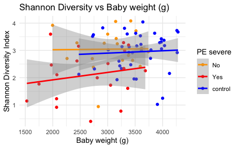

```r
#Define output directory with today's date
output_dir <- file.path("/Users/danielavargasrobles/Dropbox (UMass Medical School)/Ana_projects/2_PREECLAMPSIA/P16S/meconium/res/alpha/rlm/severe/", Sys.Date())
dir.create(output_dir, recursive = TRUE, showWarnings = FALSE)

# Save the table as a CSV file
write.csv(all_results, file = file.path(output_dir, "sev3cat_bw_No_as_ref.csv"))

p1 <- ggplot(met, aes(x = baby_weight, y = shannon, color = severe_3cat)) +
    geom_point() +
    geom_smooth(method = "lm", se = TRUE) +
    theme_minimal() +
  scale_color_manual(values = c("Yes" = "red", "No" = "orange", "control"= "blue")) +
    labs(title = "Shannon Diversity vs Baby weight (g)",
         x = "Baby weight (g)",
         y = "Shannon Diversity Index",
         color = "PE severe")

print(p1)
ggsave(filename = file.path(output_dir, "Shannon_vs_severe3cat.pdf"),
       plot = p1, width = 6, height = 4)
```

#barplot function Funcion para generar los barplot. Correr una sola vez

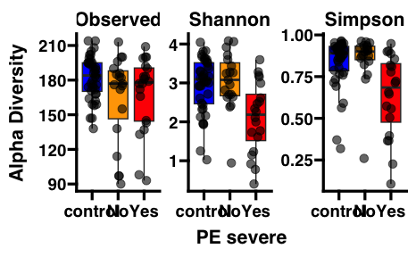

```r
library(ggprism)
library(tidyr)
library(dplyr)
phy<-PHY_fil_rar_alpha_meco
phy <- subset_samples(phy, !is.na(study_group))

#phy <- subset_samples(phy, severe_3cat != "control")

met <- data.frame(sample_data(phy))

#remove NA in severe
met <- met[!is.na(met$severe_3cat), ]


# Convertir los datos a formato largo
met_long <- met %>%
  dplyr::select(severe_3cat, observed, shannon, simpson) %>%
  pivot_longer(cols = c(observed, shannon, simpson),
               names_to = "measure",
               values_to = "value")

# Convertir measure a factor con el orden deseado
met_long$measure <- factor(met_long$measure,
                          levels = c("observed", "shannon", "simpson"),
                          labels = c("Observed", "Shannon", "Simpson"))

# Crear el gráfico
p1=ggplot(met_long, aes(x = severe_3cat, y = value, fill = severe_3cat)) +
    geom_boxplot(outlier.shape = NA) +
    geom_jitter(position = position_jitter(width = 0.2), size = 3, alpha = 0.6) +
    facet_wrap(~measure, scales = "free_y") +
    labs(x = "PE severe",
         y = "Alpha Diversity") +
    scale_fill_manual(values = c("Yes" = "red", "No" = "orange", "control"= "blue")) +
    theme_prism(base_size = 16) +
    theme(axis.text.x = element_text(size = 14),
          axis.text.y = element_text(size = 14),
          axis.title.x = element_text(size = 16),
          axis.title.y = element_text(size = 16),
          plot.title = element_text(size = 18),
          strip.text = element_text(size = 16),
          legend.title = element_text(size = 16),
          legend.text = element_text(size = 14),
          legend.position = "none")

print(p1)
ggsave(filename = file.path(output_dir, "Shannon_severe3cat.pdf"),
       plot = p1, width = 6, height = 4)
```

#actual barplot

```r
phy=PHY_fil_rar_alpha_meco

#phy_phylum=tax_glom(PHY_fil_rar_alpha_meco, taxrank= "Phylum")


colores = c("steelblue", "lightcoral", "mediumseagreen", "slateblue", "goldenrod",
"cadetblue", "tomato", "darkolivegreen", "orchid", "cornflowerblue", "darkkhaki", "turquoise", "salmon", "grey", "mediumorchid", "lightgreen", "skyblue", "sandybrown", "plum", "lightsteelblue", "peru", "darkturquoise", "rosybrown", "mediumaquamarine","palevioletred", "lightblue", "darkgrey",  "thistle", "tan", "lightslategray", "aquamarine", "indianred", "mediumslateblue","darkseagreen", "lightpink", "burlywood","powderblue", "firebrick",  "navajowhite", "seagreen", "dodgerblue", "moccasin", "chartreuse", "darkorange", "deeppink", "gold", "lavender", "palegreen","gray", "magenta", "deepskyblue", "blue", "forestgreen", "royalblue4", "mediumspringgreen", "gold3", "darkorange1", "saddlebrown", "slategray2", "seagreen", "snow4", "darkgoldenrod1", "lemonchiffon", "darkorchid", "lightskyblue", "deeppink", "khaki2", "magenta", "brown1", "cyan3", "royalblue2", "darksalmon", "lemonchiffon", "green3", "purple3", "steelblue","pink",  "chocolate1", "coral", "coral3", "coral4", "darkcyan", "cadetblue", "navajowhite3", "mediumpurple3", "bisque4")



# Function for filtering data by treshold abundance
db_sum_filter = function(phylo_object = NULL,
                         tax_cat = NULL,
                         meta_cat = NULL,
                         ref_otu = NULL,
                         treshold = 10,
                         colores = NULL) {

    # Transforming counts in proportions and extracting otu proportions
    phylo_object_prop = transform_sample_counts(phylo_object, function(x) x/sum(x))
    tax_cat_count = otu_table(phylo_object_prop)

    # Filtering tax_cat_sum treshold
    tax_cat_count0 = tax_cat_count[apply(tax_cat_count, 1, sum) >= treshold/100,]
    tax_cat_count1 = tax_cat_count[apply(tax_cat_count, 1, sum) < treshold/100,]
    df = as.data.frame(apply(tax_cat_count1, 2, sum))
    df = t(df)
    tax_tres_lab = paste0("< ", treshold, "%")
    rownames(df) = tax_tres_lab
    tax_cat_count2 = rbind(tax_cat_count0, df)

    # Extracting and processing taxonomies
    taxonomy = data.frame(tax_table(phylo_object_prop))
    tax_tres = data.frame("Kingdom" = tax_tres_lab,
                          "Phylum" = tax_tres_lab,
                          "Class" = tax_tres_lab,
                          "Order" = tax_tres_lab,
                          "Family" = tax_tres_lab,
                          "Genus" = tax_tres_lab,
                          "Species" = tax_tres_lab)#,
                         # "Strain" = NA)
    rownames(tax_tres) = tax_tres_lab
    taxonomy0 = rbind(taxonomy, tax_tres)

    # Merging taxonomies with new counts
    tax_prop = merge(taxonomy0, tax_cat_count2, by = "row.names")
    rownames(tax_prop) = tax_prop$Row.names
    tax_prop$Row.names = NULL

    # Melt dataset to have sample ids as column
    taxonomic_levels = c("Kingdom", "Phylum", "Class", "Order","Family", "Genus", "Species") # "Family",, "Strain"
    tax_prop_sample = reshape2::melt(tax_prop, id = taxonomic_levels)
    colnames(tax_prop_sample)[8] = "study_id_formated"

    # Merging melted dataset with metadata
    meta = data.frame(sample_data(phylo_object))
    tax_prop_sample_meta = merge(tax_prop_sample, meta, by.x = "study_id_formated", by.y = "row.names")

    # Generating factors and data for plotting
    db_tax = tax_prop_sample_meta %>%
        group_by(.dots = c(tax_cat)) %>%
        summarise(Abundance = sum(value)) %>%
        arrange(Abundance) %>%
        as.data.frame

    # If ref_otu is not provided setting default value
    if(is.null(ref_otu)) ref_otu = db_tax[max(which(db_tax[,tax_cat]!=tax_tres_lab)), tax_cat]

    tax_order = c(tax_tres_lab, setdiff(as.character(db_tax[,tax_cat]), c(ref_otu, tax_tres_lab)), ref_otu)

    db_plot = tax_prop_sample_meta %>%
        group_by(.dots = c("study_id_formated", tax_cat)) %>%
        summarise(Abundance = sum(value)) %>%
        as.data.frame

    sample_order = db_plot[db_plot[,tax_cat]==ref_otu,] %>%
        arrange(desc(Abundance)) %>%
        dplyr::select(study_id_formated) %>%
        unlist %>%
        as.character

    db_plot = tax_prop_sample_meta %>%
        group_by(.dots =  c("study_id_formated", tax_cat, meta_cat)) %>%
        summarise(Abundance = sum(value)) %>%
        as.data.frame

    # Reordering factors for plotting
    db_plot[,tax_cat] = factor(as.character(db_plot[,tax_cat]), levels = tax_order)
    db_plot[,"study_id_formated"] = factor(as.character(db_plot[,"study_id_formated"]), levels = sample_order)

    # Plotting
    if(!is.null(meta_cat)) {
        p = ggplot(db_plot, aes_string(x = "study_id_formated", y = "Abundance", fill= tax_cat)) +
        geom_bar(stat = "identity", position = "fill") +
        facet_grid(~get(meta_cat), scales = "free",space = "free") +
        theme(legend.position="right", legend.text=element_text(size=9)) +
        guides(fill=guide_legend(nrow=15)) +
        theme(axis.text.x = element_text(angle = 90, hjust = 1), axis.text=element_text(size=8)) +
        scale_fill_manual(values = colores[1:length(tax_order)])
    } else {
        p = ggplot(db_plot, aes_string(x = "study_id_formated", y = "Abundance", fill= tax_cat)) +
        geom_bar(stat = "identity", position = "fill") +
        theme(legend.position="right", legend.text=element_text(size=9)) +
        guides(fill=guide_legend(nrow=15)) +
        theme(axis.text.x = element_text(angle = 90, hjust = 1), axis.text=element_text(size=8)) +
        scale_fill_manual(values = colores[1:length(tax_order)])
    }




    return(list(db_plot,p))
}
```

# PCoA bray y Jaccard (testing var)

descomentar la formila a correr y editar el folder a guardarlo

```r
#remover NA
#phy <- subset_taxa(phy, !is.na(tax_table(phy)[, "Species"]) & tax_table(phy)[, "Species"] != "")

# Obtener la fecha de hoy
fecha_hoy <- Sys.Date()

# Definir la ruta completa del archivo PDF con la fecha incluida
output_file <- paste0("/Users/danielavargasrobles/Dropbox (UMass Medical School)/Ana_projects/2_PREECLAMPSIA/P16S/meconium/res/barplots/",fecha_hoy,"meco_16S_gen.pdf")

# Crear el directorio si no existe
dir.create(dirname(output_file), recursive = TRUE, showWarnings = FALSE)

# Supongamos que lista_db_p es el resultado de alguna función de análisis de datos
lista_db_p <- db_sum_filter(phylo_object = phy,
                            tax_cat = "Genus",
                           #  tax_cat = "Species",
                            #meta_cat = "body_site",
                           # meta_cat = "study_group",
                          # ref_otu = "g__Lactobacillus crispatus",
                          # ref_otu = "g__Haemophilus_parainfluenzae",
                           #ref_otu = "g__Streptococcus sp._HMT_061",
                            ref_otu = "g__Enterococcus_H_360604",
                            treshold = 20,
                            colores = colores
                           )
lista_db_p[[2]]
# Crear el archivo PDF
pdf(output_file, width = 16, height = 5)
```

```r
lista_db_p[[2]] # Reemplaza con tu código específico para generar el gráfico
dev.off()
```

# PCoA bray y Jaccard (final)

descomentar la formila a correr y editar el folder a guardarlo

```r
#load phyloseq object
#load phyloseq object
phy = PHY_fil_rar_alpha_meco

#remove NA study_group from phy
phy <- subset_samples(phy, !is.na(days_stool1))


met_phy <- data.frame(sample_data(phy))
met_phy$study_id_formated <- rownames(met_phy)
# set study_id_formated como rownames(met_phy)
rownames(met_phy) <- met_phy$study_id_formated

#phy <- prune_samples(sample_names(phy) %in% rownames(met_phy), phy)

# Asegúrate de que la tabla OTU contiene solo valores positivos
OTU_table <- transform_sample_counts(phy, function(x) x + 1) # Añadir pseudo-count

# Definir las distancias a calcular
distance_methods <- c("bray", "jaccard")

# Obtener la fecha de hoy en formato YYYY-MM-DD
fecha_hoy <- format(Sys.Date(), "%Y-%m-%d")

# Crear una carpeta con la fecha de hoy dentro de results/beta
dir.create(file.path("res/beta", fecha_hoy), showWarnings = FALSE, recursive = TRUE)

# Loop para cada método de distancia
for (method in distance_methods) {

  # Calcular la distancia
# Usá esto:
if (method == "jaccard") {
  phy_use <- phy
} else {
  phy_use <- transform_sample_counts(phy, function(x) x + 1)
}
dist_matrix <- phyloseq::distance(phy_use, method = method, binary = (method == "jaccard"))

  # Definir la fórmula para Adonis
  #form_mod <- formula(paste0("dist_matrix ~ study_group+gestational_age "))
  form_mod <- formula(paste0("dist_matrix ~ study_group + baby_weight + mod+ ethnicity+ baby_nicu+ days_stool1"))

  # Ejecutar Adonis
  set.seed(711)
  mod_adonis <- vegan::adonis2(form_mod, data = met_phy, permutations = 999, by = "margin")

  # Guardar resultados del Adonis
  output_csv <- file.path("res/beta_exploring", fecha_hoy, paste0("adonis_", method, "_baby_wei.csv"))
 # write.csv(as.data.frame(mod_adonis), file = output_csv, row.names = TRUE)

  # Realizar PCoA (MDS)
  set.seed(711)
  mds_result <- cmdscale(dist_matrix, eig = TRUE, k = 2)
mds_df <- as.data.frame(mds_result$points)
colnames(mds_df) <- c("MDS1", "MDS2")
# Cambia también rownames
rownames(mds_df) <- met_phy$study_id_formated
mds_df$study_id_formated <- rownames(mds_df)

  # Combinar coordenadas MDS con metadatos
  merged_data_mds <- merge(met_phy, mds_df, by = 0)

  # Calcular p-value y R2 del modelo Adonis
  pval <- round(mod_adonis$`Pr(>F)`[1], 3)
  r2 <- round(mod_adonis$R2[1] * 100, 1)

  # Imprimir resultados y gráfico
  print(mod_adonis)

}
```

```
Permutation test for adonis under reduced model
Marginal effects of terms
Permutation: free
Number of permutations: 999

vegan::adonis2(formula = form_mod, data = met_phy, permutations = 999, by = "margin")
            Df SumOfSqs      R2      F Pr(>F)
study_group  1   0.1216 0.00630 0.4787  0.949
baby_weight  1   0.1364 0.00706 0.5370  0.898
mod          1   0.1945 0.01008 0.7659  0.675
ethnicity    1   0.1262 0.00654 0.4968  0.956
baby_nicu    1   0.1933 0.01001 0.7611  0.685
days_stool1  1   0.3531 0.01829 1.3904  0.148
Residual    71  18.0301 0.93398
Total       77  19.3046 1.00000
Permutation test for adonis under reduced model
Marginal effects of terms
Permutation: free
Number of permutations: 999

vegan::adonis2(formula = form_mod, data = met_phy, permutations = 999, by = "margin")
            Df SumOfSqs      R2      F Pr(>F)
study_group  1   0.3238 0.01499 1.1395  0.322
baby_weight  1   0.1537 0.00712 0.5410  0.961
mod          1   0.2690 0.01246 0.9467  0.501
ethnicity    1   0.1851 0.00857 0.6512  0.890
baby_nicu    1   0.2440 0.01130 0.8586  0.616
days_stool1  1   0.2245 0.01040 0.7902  0.732
Residual    71  20.1753 0.93412
Total       77  21.5982 1.00000
```

# PCoA severe (testing var) bray y Jaccard

descomentar la formila a correr y editar el folder a guardarlo

```
Permutation test for adonis under reduced model
Marginal effects of terms
Permutation: free
Number of permutations: 999

vegan::adonis2(formula = form_mod, data = met_phy, permutations = 999, by = "margin")
            Df SumOfSqs      R2      F Pr(>F)
study_group  1   0.1800 0.00933 0.7202  0.716
days_stool1  1   0.3506 0.01816 1.4025  0.156
Residual    75  18.7472 0.97112
Total       77  19.3046 1.00000
Permutation test for adonis under reduced model
Marginal effects of terms
Permutation: free
Number of permutations: 999

vegan::adonis2(formula = form_mod, data = met_phy, permutations = 999, by = "margin")
            Df SumOfSqs      R2      F Pr(>F)
study_group  1   0.3791 0.01755 1.3494  0.174
days_stool1  1   0.1906 0.00882 0.6784  0.875
Residual    75  21.0721 0.97564
Total       77  21.5982 1.00000
```

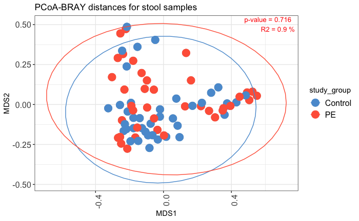

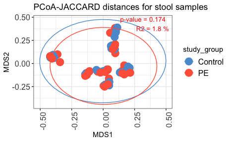

```r
#load phyloseq object
phy = PHY_fil_rar_alpha_meco

#remove NA study_group from phy
phy <- subset_samples(phy, !is.na(days_stool1))

#extract metadata from phyloseq object

met_phy <- data.frame(sample_data(phy))
met_phy$study_id_formated <- rownames(met_phy)  # <- esto es lo que falta

# set study_id_formated como rownames(met_phy)
rownames(met_phy) <- met_phy$study_id_formated

#phy <- prune_samples(sample_names(phy) %in% rownames(met_phy), phy)

# Asegúrate de que la tabla OTU contiene solo valores positivos
OTU_table <- transform_sample_counts(phy, function(x) x + 1) # Añadir pseudo-count

# Definir las distancias a calcular
distance_methods <- c("bray", "jaccard")

# Obtener la fecha de hoy en formato YYYY-MM-DD
fecha_hoy <- format(Sys.Date(), "%Y-%m-%d")

# Crear una carpeta con la fecha de hoy dentro de results/beta
dir.create(file.path("res/beta", fecha_hoy), showWarnings = FALSE, recursive = TRUE)

# Loop para cada método de distancia
for (method in distance_methods) {

  # Calcular la distancia
# Usá esto:
if (method == "jaccard") {
  phy_use <- phy
} else {
  phy_use <- transform_sample_counts(phy, function(x) x + 1)
}
dist_matrix <- phyloseq::distance(phy_use, method = method, binary = (method == "jaccard"))

  # Definir la fórmula para Adonis
  #form_mod <- formula(paste0("dist_matrix ~ study_group+gestational_age "))
  form_mod <- formula(paste0("dist_matrix ~ study_group + days_stool1 "))

  # Ejecutar Adonis
  set.seed(711)
  mod_adonis <- vegan::adonis2(form_mod, data = met_phy, permutations = 999, by = "margin")

  # Guardar resultados del Adonis
  output_csv <- file.path("res/beta", fecha_hoy, paste0("adonis_", method, "_baby_days_stool1.csv"))
 # write.csv(as.data.frame(mod_adonis), file = output_csv, row.names = TRUE)

  # Realizar PCoA (MDS)
  set.seed(711)
  mds_result <- cmdscale(dist_matrix, eig = TRUE, k = 2)
mds_df <- as.data.frame(mds_result$points)
colnames(mds_df) <- c("MDS1", "MDS2")
# Cambia también rownames
# Usar los mismos nombres que vienen del objeto de distancia
mds_df$study_id_formated <- rownames(mds_df)

# Asegúrate de que met_phy tenga esos mismos rownames
merged_data_mds <- merge(mds_df, met_phy, by = "study_id_formated")

  # Calcular p-value y R2 del modelo Adonis
  pval <- round(mod_adonis$`Pr(>F)`[1], 3)
  r2 <- round(mod_adonis$R2[1] * 100, 1)

  # Crear el gráfico
  p <- ggplot(merged_data_mds, aes(x = MDS1, y = MDS2, color = study_group)) +
       geom_point(color = "black", size = 5, shape = 1, stroke = 0.25) +

     geom_point(size = 5, alpha = 1) +
    stat_ellipse(type = "norm", level = 0.95) +
    theme_bw() +
    theme(
      axis.text.x = element_text(angle = 90, hjust = 1),
      axis.text = element_text(size = 12),
      legend.text = element_text(size = 12),
      strip.text.x = element_text(size = 12)
    ) +
    scale_color_manual(values = c( "#5a9bd4","#ff6347")) +
    ggtitle(paste0("PCoA-", toupper(method), " distances for stool samples")) +
    annotate("text", x = Inf, y = Inf, label = paste("p-value =", pval, "\nR2 =", r2, "%"),
             hjust = 1.1, vjust = 1.1, size = 3.5, color = "red")

  # Guardar el gráfico en formato PDF
  output_plot <- file.path("res/beta", fecha_hoy, paste0("PCoA_", method, "_stool_samples.pdf"))
  ggsave(output_plot, plot = p, width = 6, height = 6)

  # Imprimir resultados y gráfico
  print(mod_adonis)
  print(p)
}
```

# PCoA severe (final) bray y Jaccard

descomentar la formila a correr y editar el folder a guardarlo

```r
#load phyloseq object
phy = PHY_fil_rar_alpha_meco

#remove only severe_3cat != control
phy <- subset_samples(phy, severe_3cat != "control")


#remove NA study_group from phy
phy <- subset_samples(phy, !is.na(days_stool1))

#extract metadata from phyloseq object
met_phy <- data.frame(sample_data(phy))
met_phy$study_id_formated
```

```r
# set study_id_formated como rownames(met_phy)
rownames(met_phy) <- met_phy$study_id_formated

#phy <- prune_samples(sample_names(phy) %in% rownames(met_phy), phy)

# Asegúrate de que la tabla OTU contiene solo valores positivos
OTU_table <- transform_sample_counts(phy, function(x) x + 1) # Añadir pseudo-count

# Definir las distancias a calcular
distance_methods <- c("bray", "jaccard")

# Obtener la fecha de hoy en formato YYYY-MM-DD
fecha_hoy <- format(Sys.Date(), "%Y-%m-%d")

# Crear una carpeta con la fecha de hoy dentro de results/beta
dir.create(file.path("res/beta_exploring/severe", fecha_hoy), showWarnings = FALSE, recursive = TRUE)

# Loop para cada método de distancia
for (method in distance_methods) {

  # Calcular la distancia
# Usá esto:
if (method == "jaccard") {
  phy_use <- phy
} else {
  phy_use <- transform_sample_counts(phy, function(x) x + 1)
}
dist_matrix <- phyloseq::distance(phy_use, method = method, binary = (method == "jaccard"))

  # Definir la fórmula para Adonis
  form_mod <- formula(paste0("dist_matrix ~ severe + baby_weight + mod+ ethnicity+ baby_nicu+ days_stool1"))

  # Ejecutar Adonis
  set.seed(711)
  mod_adonis <- vegan::adonis2(form_mod, data = met_phy, permutations = 999, by = "margin")

  # Guardar resultados del Adonis
  output_csv <- file.path("res/beta_exploring", fecha_hoy, paste0("adonis_", method, "_baby_wei.csv"))
#  write.csv(as.data.frame(mod_adonis), file = output_csv, row.names = TRUE)

  # Realizar PCoA (MDS)
  set.seed(711)
  mds_result <- cmdscale(dist_matrix, eig = TRUE, k = 2)
mds_df <- as.data.frame(mds_result$points)
colnames(mds_df) <- c("MDS1", "MDS2")
# Cambia también rownames
rownames(mds_df) <- met_phy$study_id_formated
mds_df$study_id_formated <- rownames(mds_df)

  # Combinar coordenadas MDS con metadatos
  merged_data_mds <- merge(met_phy, mds_df, by = 0)

  # Calcular p-value y R2 del modelo Adonis
  pval <- round(mod_adonis$`Pr(>F)`[1], 3)
  r2 <- round(mod_adonis$R2[1] * 100, 1)

  # Imprimir resultados y gráfico
  print(mod_adonis)

}
```

```
Permutation test for adonis under reduced model
Marginal effects of terms
Permutation: free
Number of permutations: 999

vegan::adonis2(formula = form_mod, data = met_phy, permutations = 999, by = "margin")
            Df SumOfSqs      R2      F Pr(>F)
severe       1   0.5110 0.05280 1.9969  0.050 *
baby_weight  1   0.1747 0.01805 0.6827  0.730
mod          1   0.2318 0.02395 0.9059  0.486
ethnicity    1   0.2184 0.02257 0.8535  0.550
baby_nicu    1   0.1718 0.01776 0.6715  0.750
days_stool1  1   0.4030 0.04165 1.5750  0.108
Residual    31   7.9332 0.81974
Total       37   9.6777 1.00000
---
Signif. codes:  0 ‘***’ 0.001 ‘**’ 0.01 ‘*’ 0.05 ‘.’ 0.1 ‘ ’ 1
Permutation test for adonis under reduced model
Marginal effects of terms
Permutation: free
Number of permutations: 999

vegan::adonis2(formula = form_mod, data = met_phy, permutations = 999, by = "margin")
            Df SumOfSqs      R2      F Pr(>F)
severe       1   0.3191 0.02956 1.0791  0.332
baby_weight  1   0.2467 0.02285 0.8344  0.703
mod          1   0.3180 0.02946 1.0756  0.359
ethnicity    1   0.2789 0.02583 0.9432  0.544
baby_nicu    1   0.2594 0.02403 0.8774  0.626
days_stool1  1   0.2458 0.02276 0.8311  0.696
Residual    31   9.1666 0.84904
Total       37  10.7963 1.00000
```